# Exercise_3_solution

## Setting up the environment

Load ggplot2

```r
library(ggplot2)
```

Examine the mtcars dataset

```r
head(mtcars)
```

```
##                    mpg cyl disp  hp drat    wt  qsec vs am gear carb
## Mazda RX4         21.0   6  160 110 3.90 2.620 16.46  0  1    4    4
## Mazda RX4 Wag     21.0   6  160 110 3.90 2.875 17.02  0  1    4    4
## Datsun 710        22.8   4  108  93 3.85 2.320 18.61  1  1    4    1
## Hornet 4 Drive    21.4   6  258 110 3.08 3.215 19.44  1  0    3    1
## Hornet Sportabout 18.7   8  360 175 3.15 3.440 17.02  0  0    3    2
## Valiant           18.1   6  225 105 2.76 3.460 20.22  1  0    3    1
```

## Scatterplot

### Start with a simple scatterplot

Create a scatterplot from the `mtcars` dataset using `ggplot()`. Set the x variable to `disp` and the y variable to `mpg`.

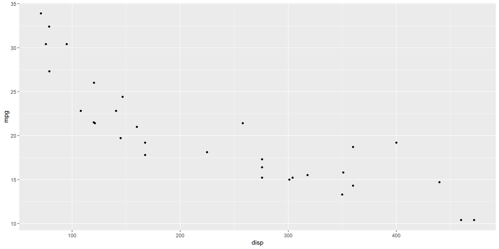

```r
ggplot(mtcars, aes(x =disp, y = mpg)) + geom_point()
```

### Add an aesthetic mapping

Map the color of the points to `wt`.

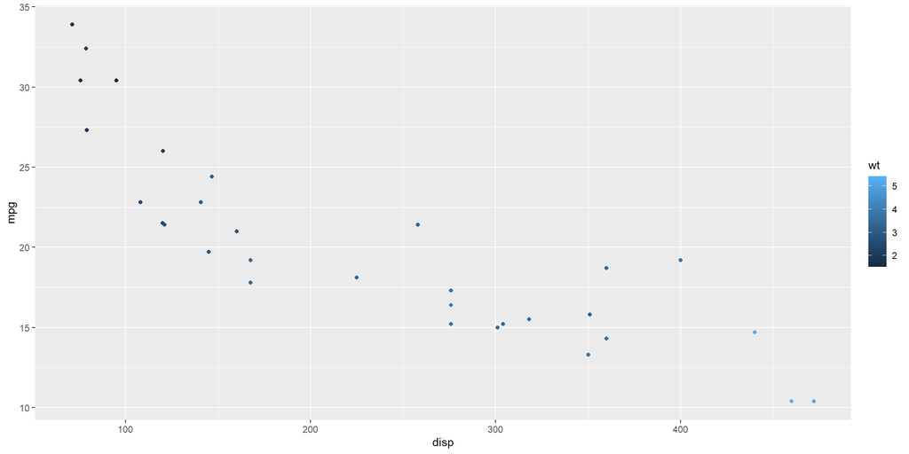

```r
ggplot(mtcars, aes(x =disp, y = mpg)) + geom_point(aes(color=wt))
```

### Customize the points

Increase the size of the points to a value of 3. Change the color scale to a gradient from low values of `green` to high values of `red`.

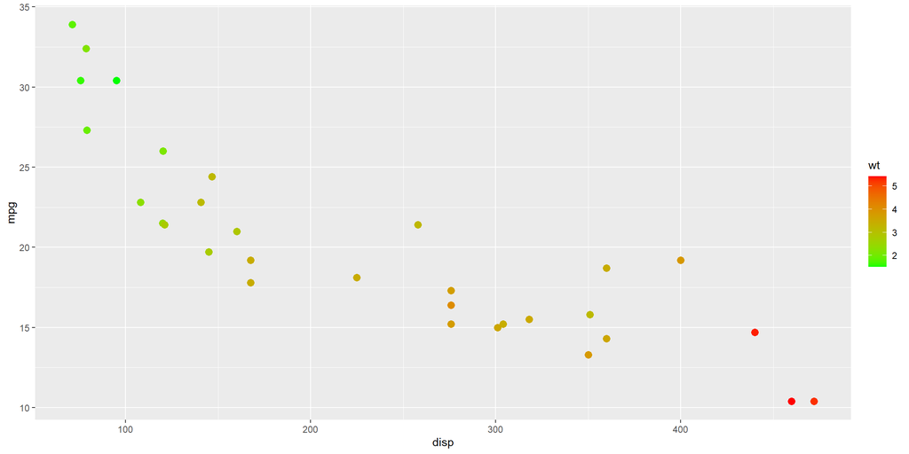

```r
mtscatter <- ggplot(mtcars, aes(x =disp, y = mpg)) +
                geom_point(aes(color=wt), size=3) +
                scale_color_gradient(low = 'green', high = 'red')

mtscatter
```

### Add another `geom_` layer

Use `geom_smooth()` and the `'lm'` method to add a regression line to the plot.

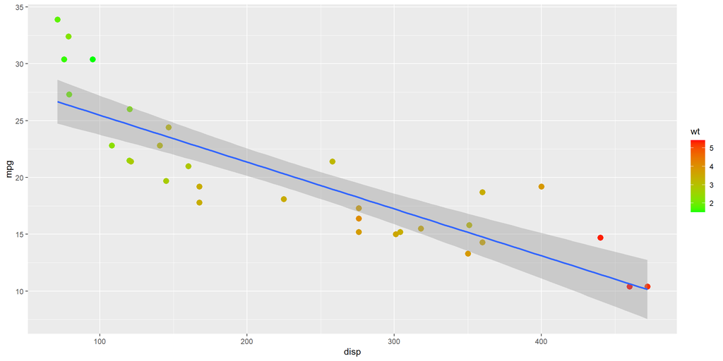

```r
mtscatter + geom_smooth(method = 'lm')
```

## Change the facet labels

Make the facet labels more descriptive using named vectors and the `facet_grid()` `labeller`.

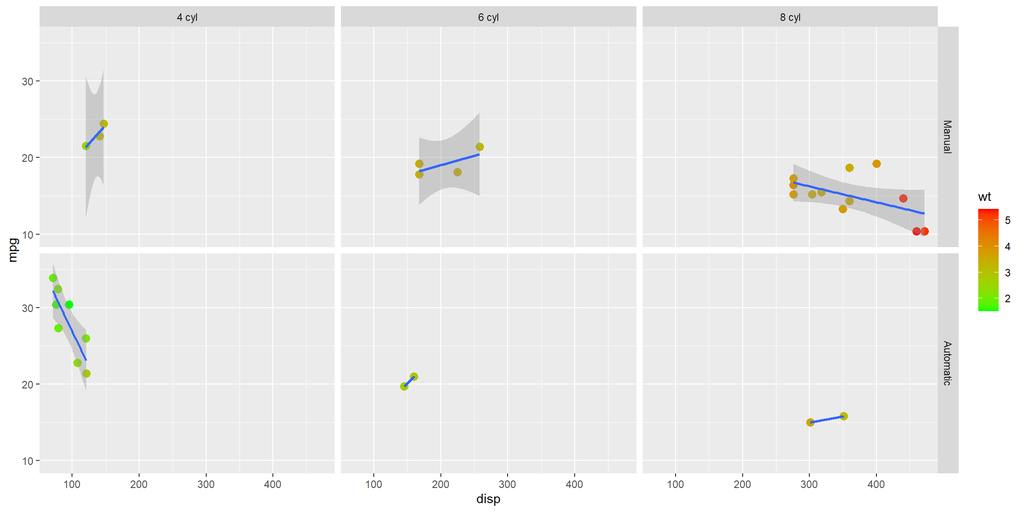

```r
# New facet label names for 'am' and 'cyl'
am.labs <- c("Manual", "Automatic")
names(am.labs) <- c(0, 1)

cyl.labs <- c("4 cyl", "6 cyl", "8 cyl")
names(cyl.labs) <- c(4, 6, 8)

# In the facet_grid function, after defining the grid,  use: labeller = labeller(am = am.labs, cyl = cyl.labs)

mtscatter +
  geom_smooth(method = 'lm') +
  facet_grid(am ~ cyl, labeller = labeller(am = am.labs, cyl = cyl.labs))
```

### Cleanup the plot

Do the following:

- ‘Free’ the x axis so that each set of plots by cylinder has its own scale
- Change the theme to black & white with a base size of 14
- Change the following titles:
  - Plot title: “Fuel Economy (1974)” - center
  - X axis title: “Displacement”
  - Y axis title: “MPG”
  - Legend title: “Weight (tons)”

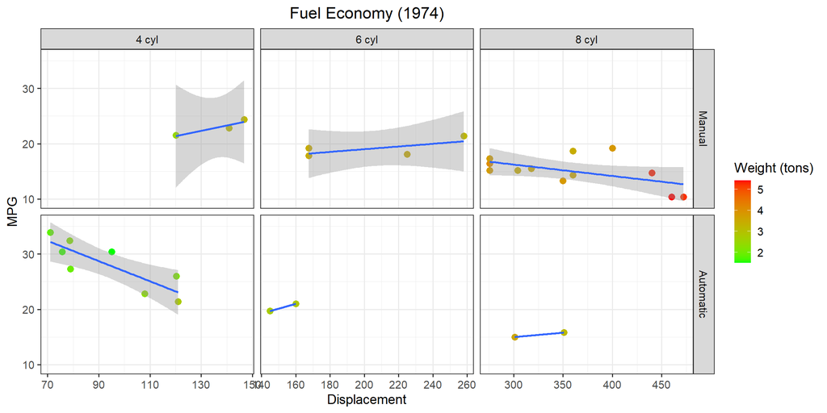

```r
mtscatter +
  geom_smooth(method = 'lm') +
  facet_grid(am ~ cyl, labeller = labeller(am = am.labs, cyl = cyl.labs), scales = "free_x") +
  theme_bw(14) +
  labs(title = "Fuel Economy (1974)", x="Displacement", y = "MPG", color= "Weight (tons)") +
  theme(plot.title = element_text(hjust=0.5))
```

## Final Changes

Now the x axis labels overlap. Fix this by adding 8mm of spacing between panels using `panel.spacing.x = unit(8, "mm")` in `theme`. Plots will resize on rendering to HTML, fixing the crowding on the x axis scale.

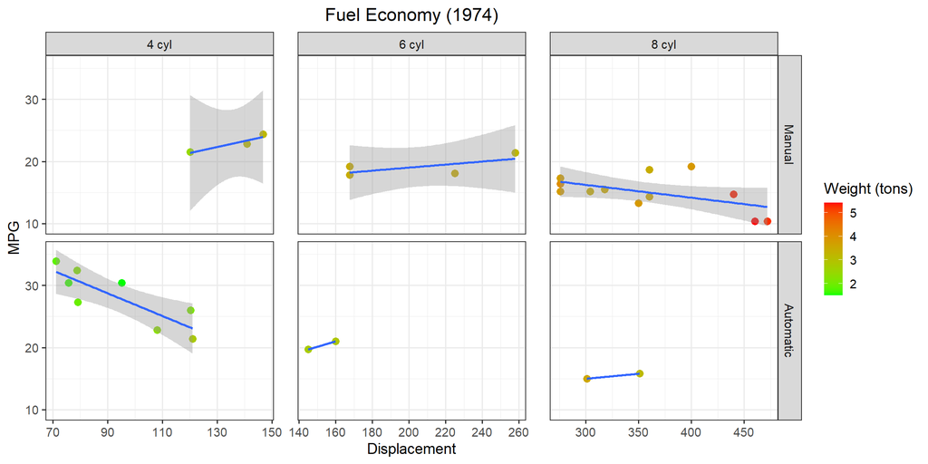

```r
mtscatter +
  geom_smooth(method = 'lm') +
  facet_grid(am ~ cyl, labeller = labeller(am = am.labs, cyl = cyl.labs), scales = "free_x") +
  theme_bw(14) +
  labs(title = "Fuel Economy (1974)", x="Displacement", y = "MPG", color= "Weight (tons)") +
  theme(plot.title = element_text(hjust=0.5), panel.spacing.x = unit(8, "mm"))
```